# Лабораторная работа №8

Реализация основных моделей в дискретно-событийном подходе

Софич Андрей Геннадьевич

safich05@mail.ru

Российский университет дружбы народов

2026-30-05

## Докладчик

- Софич Андрей Геннадьевич

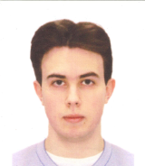

# Актуальность

## Актуальность

Изучить дискретно-событийный подход к имитационному моделированию на примере классической модели распространения инфекции SIR.

# Цель

## Цели и задачи

# Выполнение лабораторной работы

## Выполнение лабораторной работы

Создаем рабочий каталог и инициализируем проект в julia

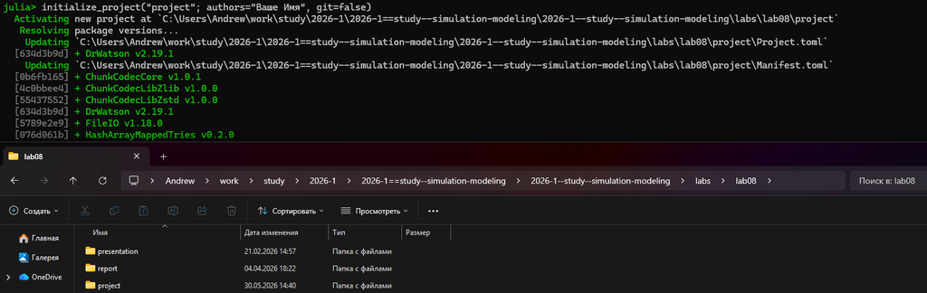

Инициализация проекта

Создаем файл, где прописываем пакеты, необходимые для выполнения работы и запускаем его

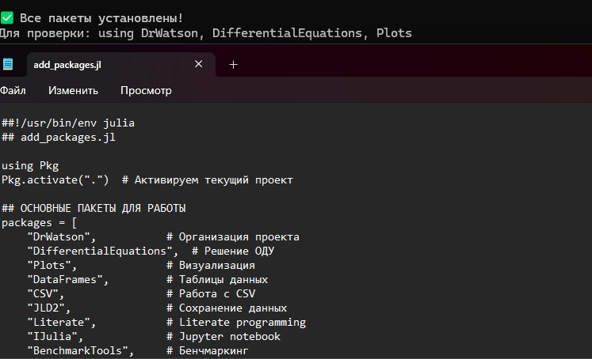

Подключение необходимых пакетов

Создаем файл в папке src, реализуем в нем модель SIR, определяем структуру данных, входные данные, прописываем функции мутации масивов статистики

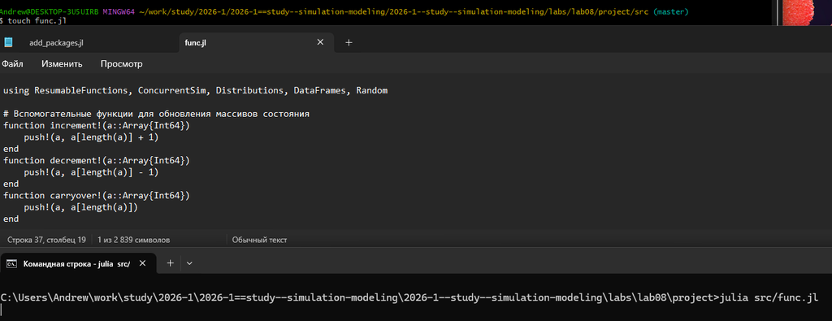

Создание файла для реализации SIR

Прописываем и запускаем скрипт запуска, прописываем начальные параметры и запускаем симуляцию

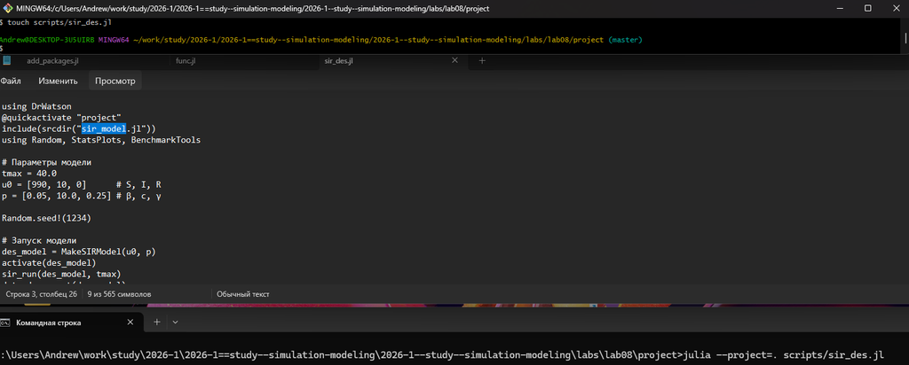

Скрипт симуляции

Получаем результаты, на которых отлично видно структуру поведения агентов: восприимчивый-зараженный-выздоровевший

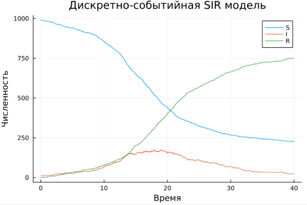

График

Преобразовываем код в произвольные стили и открываем один из них, чтобы убедиться в правильности компиляции

[figure not shown]

Код в стиле jupyter notebook

Заменяем экспоненциальное время выздоровления на фиксированную величину 1/γ в файле src

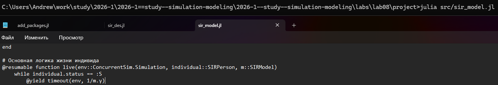

Замена файла

Запускаем файл симуляции и смотрим на результаты до и после, отсутсвуют хвосты распределения и выздоровлее стало более синхронным

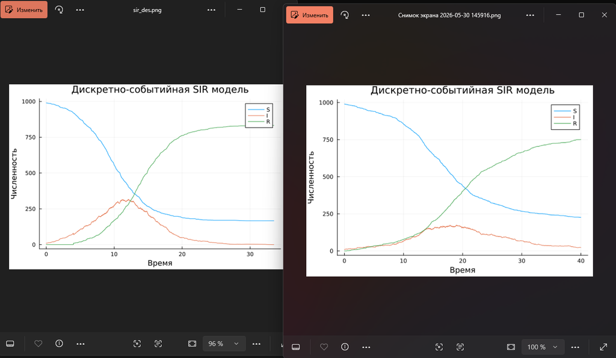

Сравнение графиков

Добавляем возможность получать статистические данные в виде таблицы

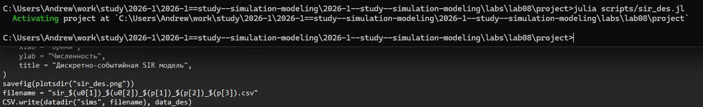

Добавление таблицы

Проверяем таблицу с данными

[figure not shown]

Таблица с данными SIR

Преобразовываем код в произвольные стили и открываем один из них, чтобы убедиться в правильности компиляции

[figure not shown]

Код в стиле jupyter notebook

# Выводы

## Выводы

В данной работе мы изучили и применили дискретно-событийное моделирование.